# IE 48A - Assignment 3: Esoph and Young People Survey

Irmak Dai

This report consists of two sections. In the first section I will analyze `esoph` data to see if esophageal cancer is related to age or alcohol & tobacco consumption. Data is from a case-control study of esophageal cancer in Ille-et-Vilaine, France.

In the second section I will work on the dataset [Young People Survey’s Hobbies & Interests](https://www.kaggle.com/miroslavsabo/young-people-survey) with the purpose of inferring meaning from the data.

To get more info about this assignment please visit [assignment page](https://mef-bda503.github.io/archive/fall17/files/assignment_youth_survey.html) and [IE 48A Course Webpage](https://boun-ie48a.github.io/).

# 1 Esoph Data Analysis

## 1.1 Preparation

```r
library(tidyverse)
esoph_data <- esoph
str(esoph_data)
```

```
## 'data.frame':    88 obs. of  5 variables:
##  $ agegp    : Ord.factor w/ 6 levels "25-34"<"35-44"<..: 1 1 1 1 1 1 1 1 1 1 ...
##  $ alcgp    : Ord.factor w/ 4 levels "0-39g/day"<"40-79"<..: 1 1 1 1 2 2 2 2 3 3 ...
##  $ tobgp    : Ord.factor w/ 4 levels "0-9g/day"<"10-19"<..: 1 2 3 4 1 2 3 4 1 2 ...
##  $ ncases   : num  0 0 0 0 0 0 0 0 0 0 ...
##  $ ncontrols: num  40 10 6 5 27 7 4 7 2 1 ...
```

```r
summary(esoph_data)
```

```
##    agegp          alcgp         tobgp        ncases         ncontrols
##  25-34:15   0-39g/day:23   0-9g/day:24   Min.   : 0.000   Min.   : 1.00
##  35-44:15   40-79    :23   10-19   :24   1st Qu.: 0.000   1st Qu.: 3.00
##  45-54:16   80-119   :21   20-29   :20   Median : 1.000   Median : 6.00
##  55-64:16   120+     :21   30+     :20   Mean   : 2.273   Mean   :11.08
##  65-74:15                                3rd Qu.: 4.000   3rd Qu.:14.00
##  75+  :11                                Max.   :17.000   Max.   :60.00
```

```r
pal <- c("#7B40E4","#D363D8","#F18A92","#F4CD83","#71EAD7","#98f093")
```

I noticed that “g/day” exists in some columns

```r
esoph_data$alcgp <- gsub("g/day","",esoph_data$alcgp)
esoph_data$tobgp <- gsub("g/day","",esoph_data$tobgp)
```

Making them ordered factors again

```r
esoph_data$alcgp <- factor(esoph_data$alcgp, ordered = TRUE, levels = c("0-39","40-79","80-119","120+"))
esoph_data$tobgp <- factor(esoph_data$tobgp, ordered = TRUE, levels = c("0-9","10-19","20-29","30+"))
```

Creating total patients and ratio of cases column

```r
esoph_data <- esoph_data %>%
  mutate(ntotal=ncases+ncontrols, case_ratio=ncases/ntotal)
```

Our task is to find relations between variables and whether people have oesophageal cancer or not. The dataset consists of categorical variables instead of linear variables (e.g. we do not have the exact age of the participants). I used the name “case_ratio” instead of “case_probability” since the data is not plentiful, I did not feel comfortable using the term probability.

## 1.2 Histograms

You can see the histograms in different tabs below:

### 1.2.1 Number of cases

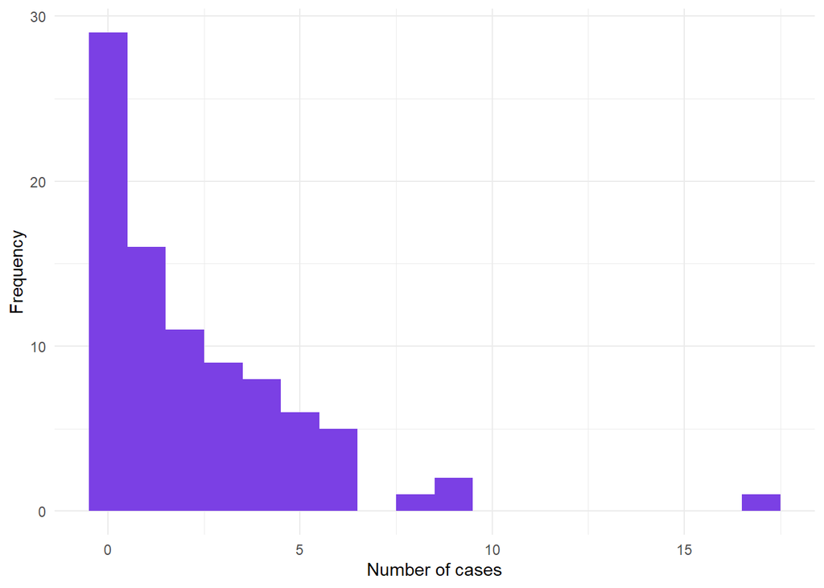

```r
ggplot(esoph_data, aes(ncases))+
  geom_histogram(binwidth = 1, fill=pal[1])+
  theme_minimal()+
  labs(x="Number of cases",y="Frequency")
```

There are many groups in which zero or just a few cases exist. There is only one category in which 10+ cases are found.

### 1.2.2 Number of participants

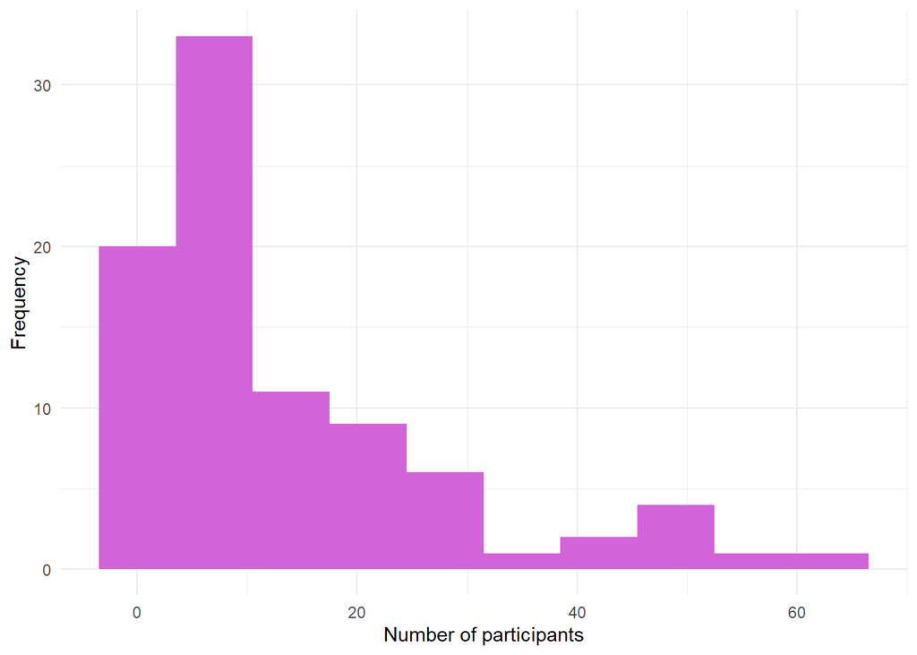

```r
ggplot(esoph_data, aes(ntotal))+
  geom_histogram(binwidth = 7, fill=pal[2])+
  theme_minimal()+
  labs(x="Number of participants", y="Frequency")
```

We see that most of the categories have less than 10 participants.

### 1.2.3 Case ratio

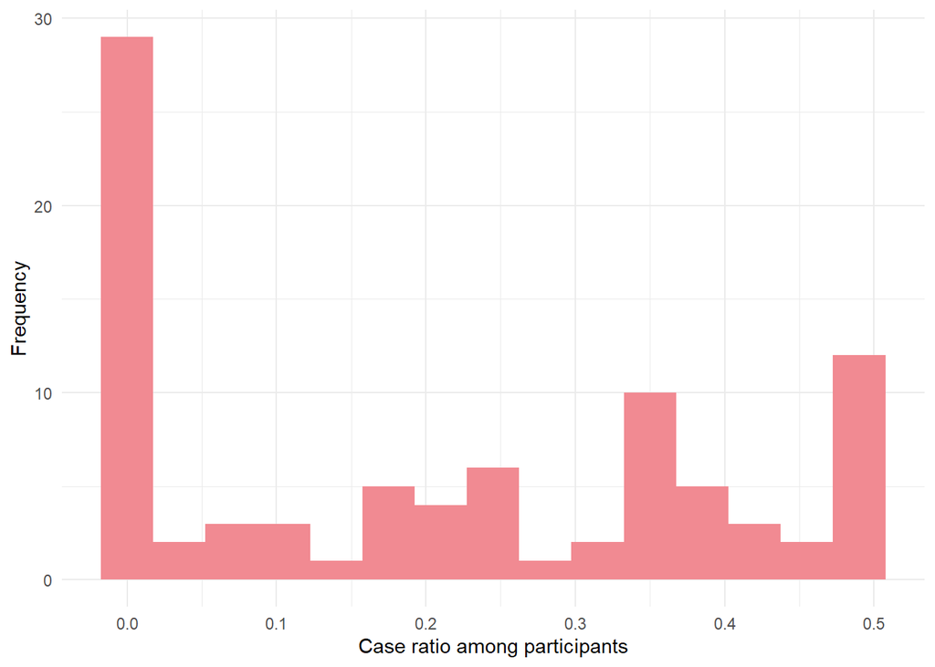

```r
ggplot(esoph_data, aes(case_ratio))+
  geom_histogram(fill=pal[3], binwidth = 0.035)+
  theme_minimal()+
  labs(x="Case ratio among participants", y="Frequency")
```

Most of the categories have very low case ratios whereas there are considerable number of categories in which ratio is higher than 0.3.

## 1.3 Relation with age

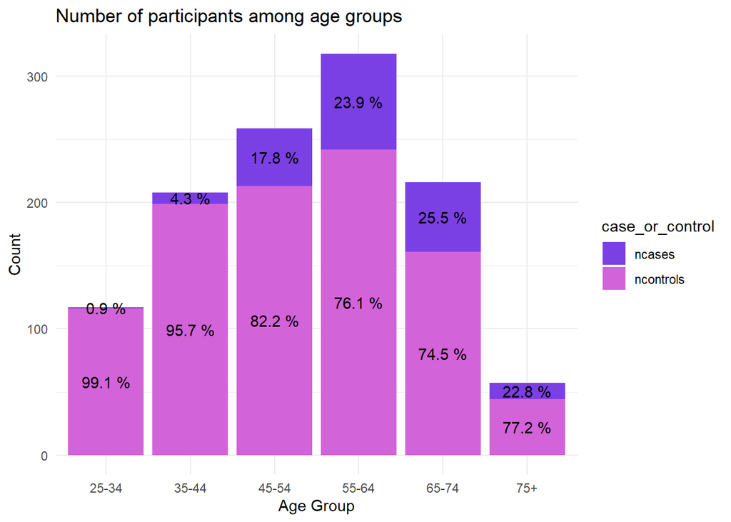

```r
esoph_by_agegp <- esoph_data %>%
  group_by(agegp) %>%
  summarise(ncases=sum(ncases), ncontrols=sum(ncontrols), ntotal=sum(ntotal))
esoph_by_agegp_arranged <- esoph_by_agegp %>%
  pivot_longer(cols = c("ncases","ncontrols"), names_to="case_or_control", values_to="count")

ggplot(esoph_by_agegp_arranged, aes(x=agegp,y=count,fill=case_or_control, label=paste(round(count/ntotal,3)*100,"%")))+
  geom_bar(stat = "identity")+
  scale_fill_manual(values=pal)+
  theme_minimal()+
  geom_text(position = position_stack(vjust = 0.5))+
  labs(x = "Age Group", y = "Count", title = "Number of participants among age groups")
```

We see that number of participants varies in age groups.  
The fact that case ratio of 65-74 age group is higher than 75+ age group may be interesting. This may be caused by the fact that 75+ age group has relatively less participants, or maybe people who develop esophageal cancer may not live that longer. Nevertheless we have enough evidence to say that esophageal cancer is more common in the older age groups, thus is related to age.

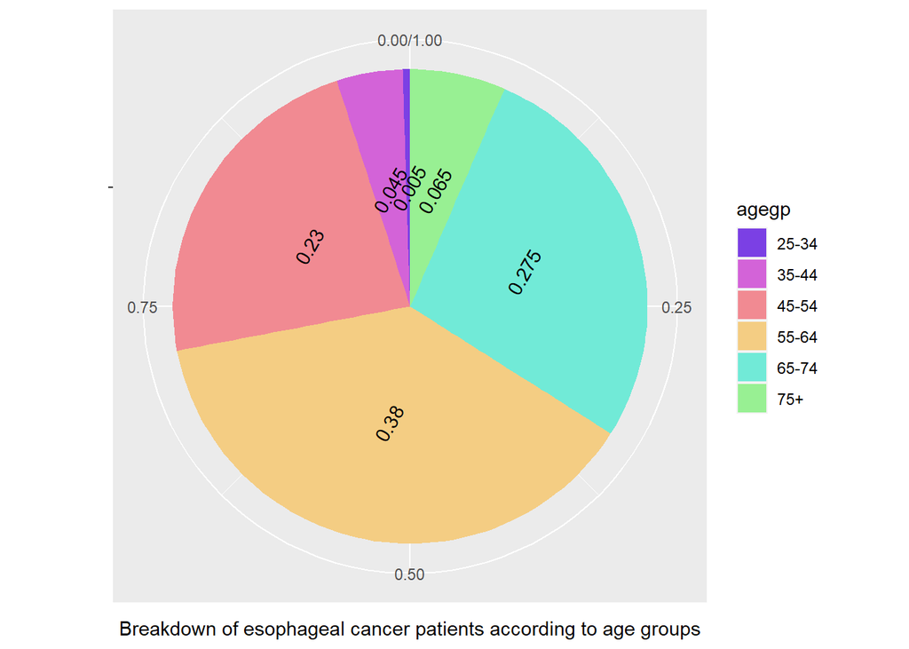

```r
ggplot(esoph_by_agegp, aes(x="",y=ncases/sum(ncases),fill=agegp, label=ncases/sum(ncases)))+
  geom_bar(stat="identity",width=1)+coord_polar("y")+
  labs(x="",y="Breakdown of esophageal cancer patients according to age groups")+
  scale_fill_discrete(name="Age groups")+
  geom_text(position = position_stack(vjust = 0.5), angle=60)+
  scale_fill_manual(values = pal)
```

We see that most of the esophageal cancer patients that participated in this research belong the age groups “55-64”, “65-74” and “45-54”. This pie chart would br very different if number of participants in the different age groups were equal.

## 1.4 Relation with alcohol consumption

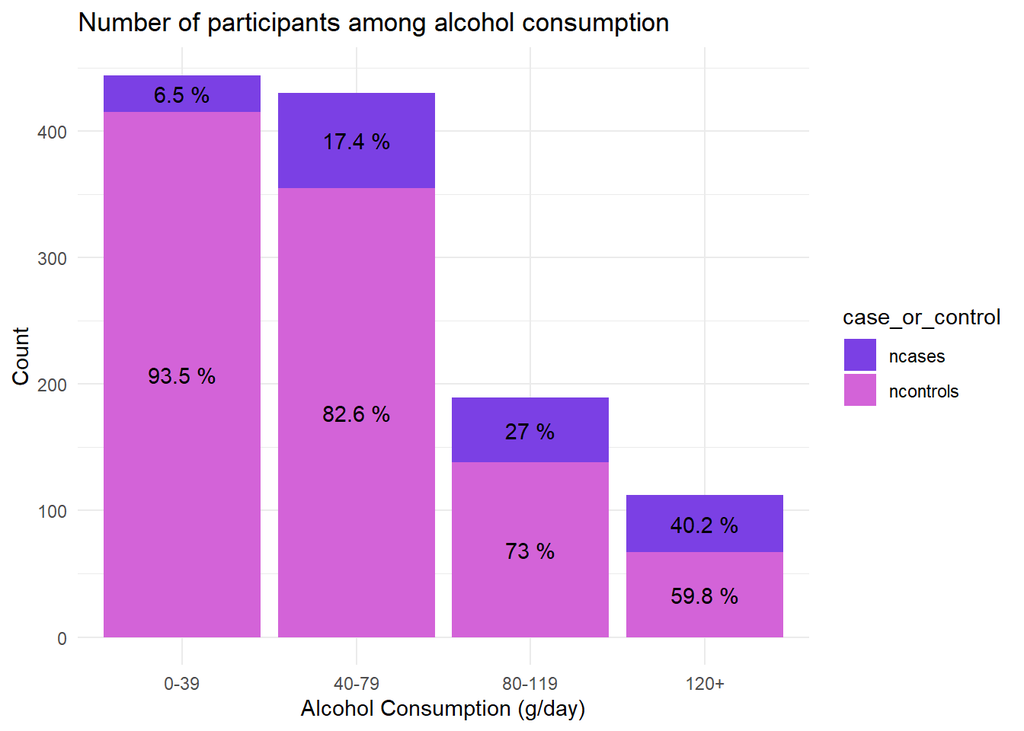

```r
esoph_by_alcgp <- esoph_data %>%
  group_by(alcgp) %>%
  summarise(ncases=sum(ncases), ncontrols=sum(ncontrols), ntotal=sum(ntotal), case_ratio=ncases/ntotal)

esoph_by_alcgp_arranged <- esoph_by_alcgp %>%
  pivot_longer(cols = c("ncases","ncontrols"), names_to="case_or_control", values_to="count")

ggplot(esoph_by_alcgp_arranged, aes(x=alcgp,y=count,fill=case_or_control, label=paste(round(count/ntotal,3)*100,"%")))+
  geom_bar(stat = "identity")+
  scale_fill_manual(values=pal)+
  theme_minimal()+
  geom_text(position = position_stack(vjust = 0.5))+
  labs(x = "Alcohol Consumption (g/day)", y = "Count", title = "Number of participants among alcohol consumption")
```

It is clear that people who consume alcohol more are more likely to develop esopheagal cancer. It is worth to remark the significant difference between case ratios of “0-39” and “40-79” alcohol consumption groups.

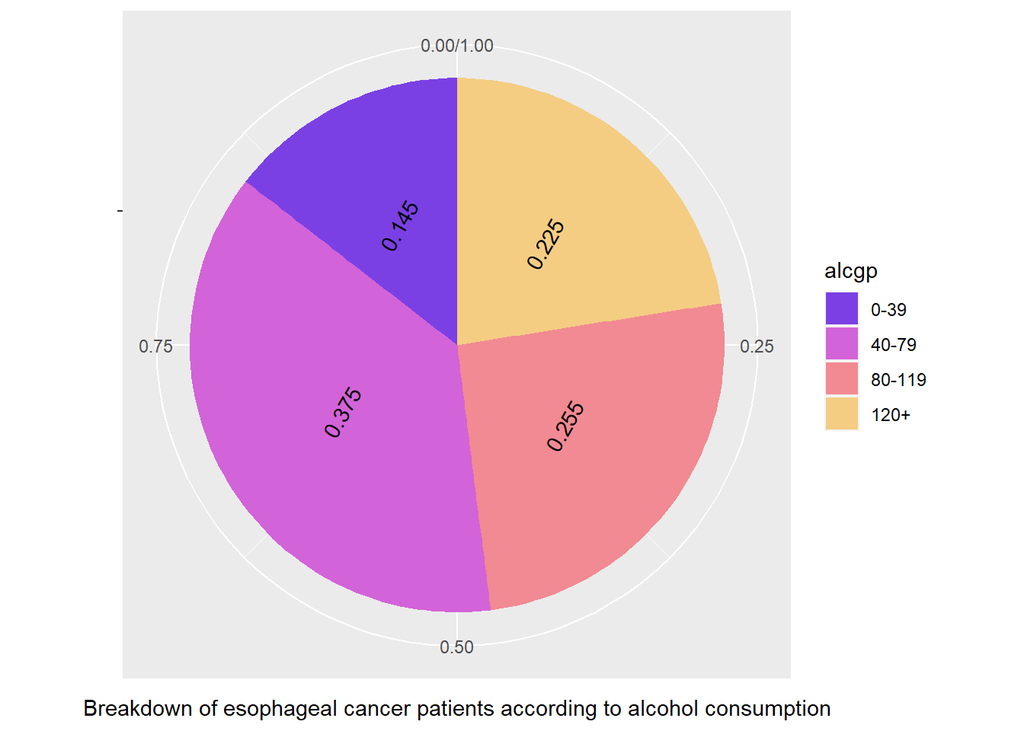

```r
ggplot(esoph_by_alcgp, aes(x="",y=ncases/sum(ncases),fill=alcgp, label=ncases/sum(ncases)))+
  geom_bar(stat="identity",width=1)+coord_polar("y")+
  labs(x="",y="Breakdown of esophageal cancer patients according to alcohol consumption")+
  scale_fill_discrete(name="Alcohol consumption (g/day)")+
  geom_text(position = position_stack(vjust = 0.5), angle=60)+
  scale_fill_manual(values = pal)
```

Even if “80-119” and “120+” alcohol consumption groups constitute a small part of the participants, we see that they constitute a large part of cancer patients.

## 1.5 Relation with tobacco consumption

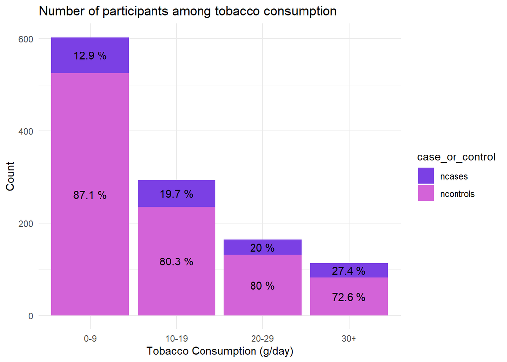

```r
esoph_by_tobgp <- esoph_data %>%
  group_by(tobgp) %>%
  summarise(ncases=sum(ncases), ncontrols=sum(ncontrols), ntotal=sum(ntotal), case_ratio=ncases/ntotal)

esoph_by_tobgp_arranged <- esoph_by_tobgp %>%
  pivot_longer(cols = c("ncases","ncontrols"), names_to="case_or_control", values_to="count")

ggplot(esoph_by_tobgp_arranged, aes(x=tobgp,y=count, fill=case_or_control, label=paste(round(count/ntotal,3)*100,"%")))+
  geom_bar(stat = "identity")+
  scale_fill_manual(values=pal)+
  theme_minimal()+
  geom_text(position = position_stack(vjust = 0.5))+
  labs(x = "Tobacco Consumption (g/day)", y = "Count", title = "Number of participants among tobacco consumption")
```

We have enough evidence to say that tobacco consumption increases the risk of esophageal cancer. Also it took my attention that the effect of tobacco consumption on esophageal cancer seems less than the effect of alcohol consumption.

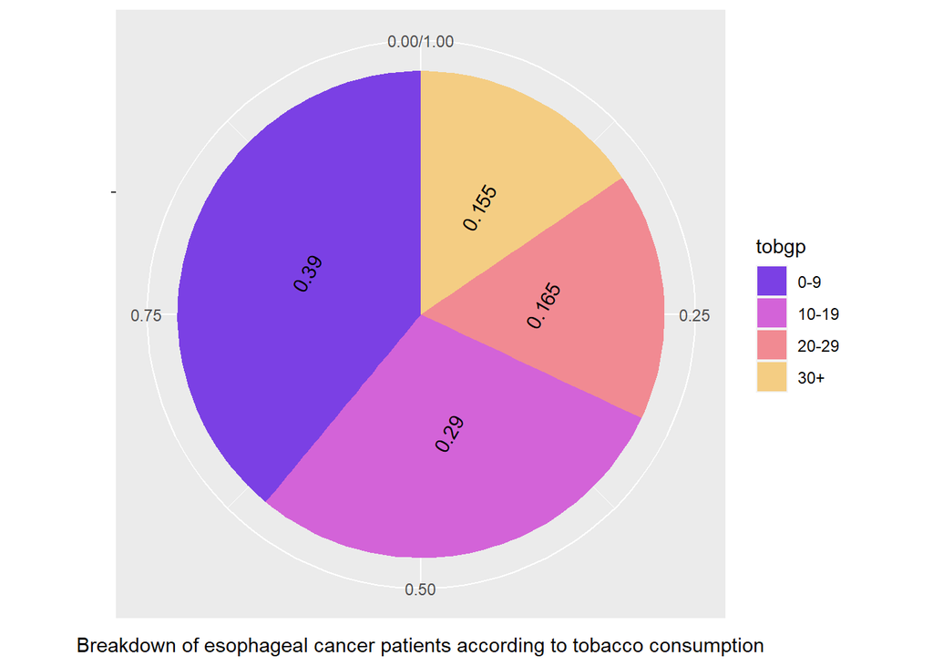

```r
ggplot(esoph_by_tobgp, aes(x="",y=ncases/sum(ncases),fill=tobgp, label=ncases/sum(ncases)))+
  geom_bar(stat="identity",width=1)+coord_polar("y")+
  labs(x="",y="Breakdown of esophageal cancer patients according to tobacco consumption")+
  scale_fill_discrete(name="Tobacco consumption (g/day)")+
  geom_text(position = position_stack(vjust = 0.5), angle=60)+
  scale_fill_manual(values = pal)
```

Also I plotted another heatmap to see effects of alcohol and tobacco together.

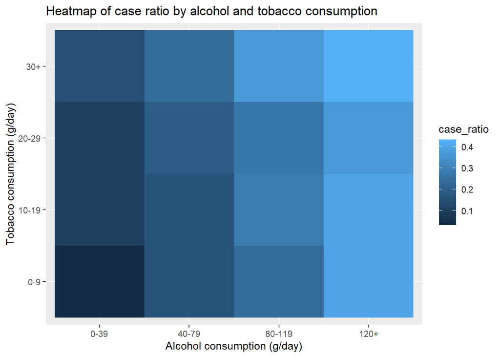

```r
esoph_by_alcgp_tobgp <- esoph_data %>%
  group_by(alcgp, tobgp) %>%
  summarise(ncases=sum(ncases), ntotal=sum(ntotal)) %>%
  mutate(case_ratio=ncases/ntotal)

ggplot(esoph_by_alcgp_tobgp, aes(x=alcgp, y=tobgp, fill=case_ratio)) +
  geom_tile() +
  labs(x = "Alcohol consumption (g/day)",
       y = "Tobacco consumption (g/day)",
       title = "Heatmap of case ratio by alcohol and tobacco consumption")
```

## 1.6 Logistic Regression

Here is a logistic regression model to predict proportion of cases among participants.

```r
lg_model <- glm(cbind(ncases,ncontrols)~agegp+alcgp*tobgp, family = binomial, data = esoph_data)
anova(lg_model)
```

```
## Analysis of Deviance Table
##
## Model: binomial, link: logit
##
## Response: cbind(ncases, ncontrols)
##
## Terms added sequentially (first to last)
##
##
##             Df Deviance Resid. Df Resid. Dev
## NULL                           87    227.241
## agegp        5   88.128        82    139.112
## alcgp        3   74.541        79     64.572
## tobgp        3   10.599        76     53.973
## alcgp:tobgp  9    6.489        67     47.484
```

```r
summary(lg_model)
```

```
##
## Call:
## glm(formula = cbind(ncases, ncontrols) ~ agegp + alcgp * tobgp,
##     family = binomial, data = esoph_data)
##
## Deviance Residuals:
##     Min       1Q   Median       3Q      Max
## -1.8895  -0.5317  -0.2304   0.2704   2.0724
##
## Coefficients:
##                 Estimate Std. Error z value Pr(>|z|)
## (Intercept)     -1.75985    0.19822  -8.878  < 2e-16 ***
## agegp.L          2.99646    0.65386   4.583 4.59e-06 ***
## agegp.Q         -1.35008    0.59197  -2.281   0.0226 *
## agegp.C          0.13436    0.45056   0.298   0.7655
## agegp^4          0.07098    0.30974   0.229   0.8187
## agegp^5         -0.21347    0.19627  -1.088   0.2768
## alcgp.L          1.37077    0.21136   6.485 8.85e-11 ***
## alcgp.Q         -0.14913    0.19645  -0.759   0.4478
## alcgp.C          0.22823    0.18203   1.254   0.2099
## tobgp.L          0.63846    0.19710   3.239   0.0012 **
## tobgp.Q          0.02922    0.19617   0.149   0.8816
## tobgp.C          0.15607    0.19796   0.788   0.4304
## alcgp.L:tobgp.L -0.70426    0.41128  -1.712   0.0868 .
## alcgp.Q:tobgp.L  0.12948    0.38889   0.333   0.7392
## alcgp.C:tobgp.L -0.16118    0.36697  -0.439   0.6605
## alcgp.L:tobgp.Q  0.12225    0.42044   0.291   0.7712
## alcgp.Q:tobgp.Q -0.44527    0.39224  -1.135   0.2563
## alcgp.C:tobgp.Q  0.04843    0.36211   0.134   0.8936
## alcgp.L:tobgp.C -0.29187    0.42939  -0.680   0.4967
## alcgp.Q:tobgp.C -0.05205    0.39538  -0.132   0.8953
## alcgp.C:tobgp.C -0.13905    0.35754  -0.389   0.6973
## ---
## Signif. codes:  0 '***' 0.001 '**' 0.01 '*' 0.05 '.' 0.1 ' ' 1
##
## (Dispersion parameter for binomial family taken to be 1)
##
##     Null deviance: 227.241  on 87  degrees of freedom
## Residual deviance:  47.484  on 67  degrees of freedom
## AIC: 236.96
##
## Number of Fisher Scoring iterations: 6
```

```r
perf <- broom::glance(lg_model)
pseudoR2 <- 1 - perf$deviance/perf$null.deviance

paste("PseudoR2 value for logistic regression model is", round(pseudoR2,2))
```

```
## [1] "PseudoR2 value for logistic regression model is 0.79"
```

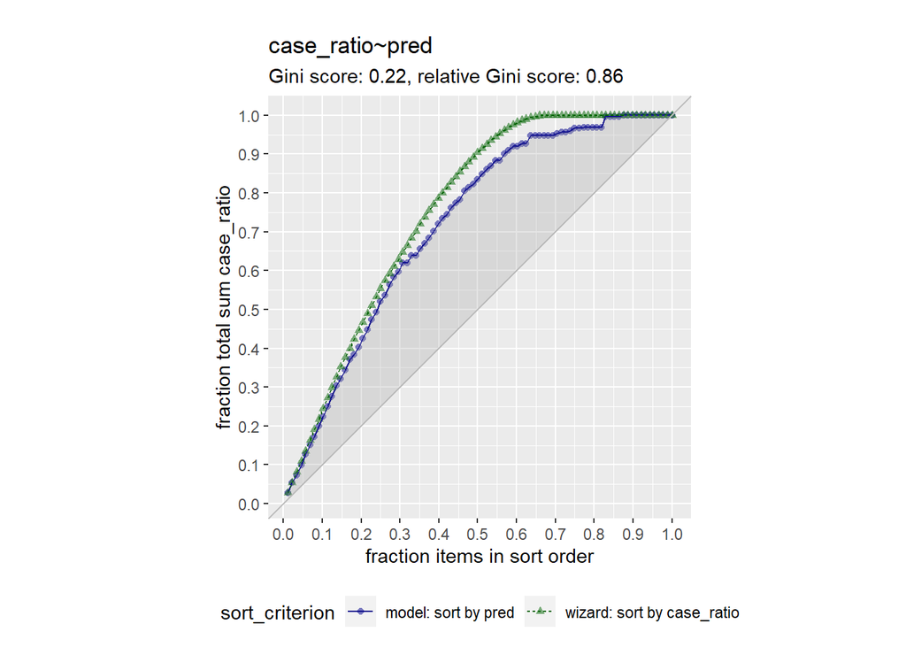

```r
esoph_data$pred <- predict(lg_model,type="response")

WVPlots::GainCurvePlot(esoph_data, "pred", "case_ratio","")
```

# 2 Young People Survey

## 2.1 Preparation

Columns that I should work on are selected and NAs in the data are cleaned.

```r
columns <- read.csv("columns.csv")
responses <- read.csv("responses.csv")

filtered_responses <- responses %>%
  select("History":"Pets")

str(filtered_responses)
```

```
## 'data.frame':    1010 obs. of  32 variables:
##  $ History               : int  1 1 1 4 3 5 3 5 3 3 ...
##  $ Psychology            : int  5 3 2 4 2 3 3 2 2 2 ...
##  $ Politics              : int  1 4 1 5 3 4 1 3 1 3 ...
##  $ Mathematics           : int  3 5 5 4 2 2 1 1 1 3 ...
##  $ Physics               : int  3 2 2 1 2 3 1 1 1 1 ...
##  $ Internet              : int  5 4 4 3 2 4 2 5 1 5 ...
##  $ PC                    : int  3 4 2 1 2 4 1 4 1 1 ...
##  $ Economy.Management    : int  5 5 4 2 2 1 3 1 1 4 ...
##  $ Biology               : int  3 1 1 3 3 4 5 2 3 2 ...
##  $ Chemistry             : int  3 1 1 3 3 4 5 2 1 1 ...
##  $ Reading               : int  3 4 5 5 5 3 3 2 5 4 ...
##  $ Geography             : int  3 4 2 4 2 3 3 3 1 4 ...
##  $ Foreign.languages     : int  5 5 5 4 3 4 4 4 1 5 ...
##  $ Medicine              : int  3 1 2 2 3 4 5 1 1 1 ...
```

[output cut: 18 more lines]

```r
filtered_responses=filtered_responses[complete.cases(filtered_responses),]
```

## 2.2 Principle Component Analysis

```r
survey_pca <- princomp(as.matrix(filtered_responses), cor = T)
summary(survey_pca,loadings=TRUE)
```

```
## Importance of components:
##                           Comp.1    Comp.2     Comp.3     Comp.4     Comp.5
## Standard deviation     2.0433958 1.8069970 1.60438109 1.46391156 1.26463164
## Proportion of Variance 0.1304833 0.1020387 0.08043871 0.06696991 0.04997791
## Cumulative Proportion  0.1304833 0.2325220 0.31296072 0.37993063 0.42990854
##                            Comp.6     Comp.7     Comp.8     Comp.9    Comp.10
## Standard deviation     1.18461175 1.06955650 1.05602251 1.04363010 1.00633062
## Proportion of Variance 0.04385328 0.03574847 0.03484949 0.03403637 0.03164692
## Cumulative Proportion  0.47376182 0.50951029 0.54435978 0.57839615 0.61004306
##                           Comp.11    Comp.12    Comp.13    Comp.14    Comp.15
## Standard deviation     0.95951254 0.93789360 0.93168719 0.89503805 0.87262765
## Proportion of Variance 0.02877076 0.02748889 0.02712628 0.02503416 0.02379622
## Cumulative Proportion  0.63881382 0.66630271 0.69342899 0.71846315 0.74225937
##                           Comp.16   Comp.17    Comp.18    Comp.19    Comp.20
## Standard deviation     0.85510068 0.8329419 0.80296355 0.78632469 0.76747805
## Proportion of Variance 0.02284991 0.0216810 0.02014845 0.01932208 0.01840695
## Cumulative Proportion  0.76510928 0.7867903 0.80693874 0.82626082 0.84466777
##                           Comp.21    Comp.22    Comp.23    Comp.24    Comp.25
## Standard deviation     0.74821762 0.72513227 0.71054805 0.70905599 0.69087699
## Proportion of Variance 0.01749468 0.01643178 0.01577745 0.01571126 0.01491597
## Cumulative Proportion  0.86216245 0.87859422 0.89437168 0.91008294 0.92499891
##                           Comp.26    Comp.27    Comp.28   Comp.29     Comp.30
## Standard deviation     0.65750430 0.64296368 0.60888823 0.5954011 0.551814415
## Proportion of Variance 0.01350975 0.01291882 0.01158578 0.0110782 0.009515598
## Cumulative Proportion  0.93850866 0.95142748 0.96301326 0.9740915 0.983607058
##                            Comp.31     Comp.32
## Standard deviation     0.539017589 0.483770803
## Proportion of Variance 0.009079374 0.007313568
## Cumulative Proportion  0.992686432 1.000000000
##
## Loadings:
##                        Comp.1 Comp.2 Comp.3 Comp.4 Comp.5 Comp.6 Comp.7 Comp.8
## History                 0.196         0.184  0.243  0.130  0.243  0.142  0.194
## Psychology              0.244                0.119  0.112        -0.102
## Politics                0.131  0.202  0.255  0.204  0.270  0.153        -0.108
## Mathematics                    0.295 -0.126  0.133        -0.309 -0.220 -0.273
## Physics                        0.344 -0.241  0.136        -0.155 -0.151 -0.151
## Internet                       0.237  0.127               -0.400         0.370
## PC                             0.377               -0.134 -0.291  0.137  0.144
## Economy.Management             0.174  0.306         0.214 -0.182 -0.166 -0.288
```

[output cut: 141 more lines]

```
## Religion               -0.111
## Countryside..outdoors
## Dancing
## Musical.instruments
## Writing                         0.150
## Passive.sport
## Active.sport
## Gardening
## Celebrities
## Shopping                0.134
## Science.and.technology
## Theatre                -0.175   0.161
## Fun.with.friends
## Adrenaline.sports
## Pets
```

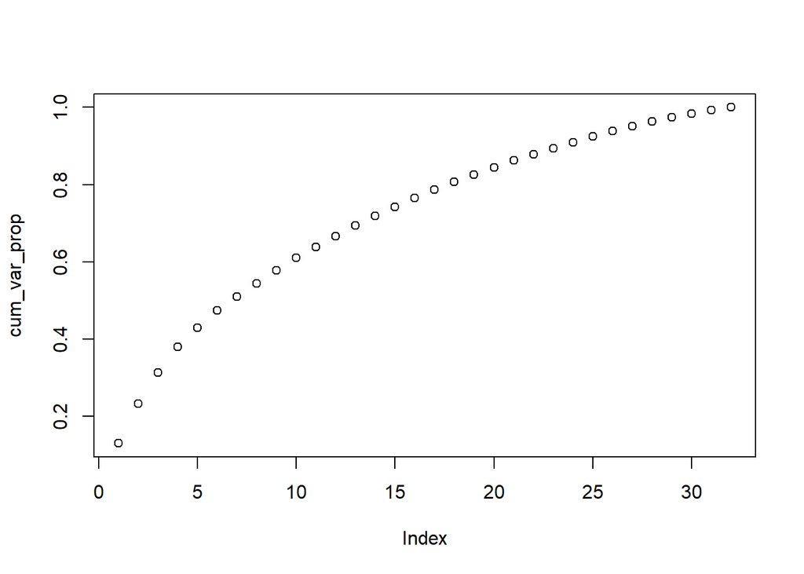

```r
sdev <- survey_pca$sdev
var <- sdev^2
var_prop <- var/sum(var)
cum_var_prop <- cumsum(var_prop)

plot(cum_var_prop)
```

We see that first 18 PCs are responsible for 80% of variation.

## 2.3 Multidimensional Scaling

```r
dist_matrix <- 1 - cor(filtered_responses)
mds_data <- cmdscale(dist_matrix, k=2)
colnames(mds_data) <- c("x","y")
mds_data
```

```
##                                  x            y
## History                 0.06372563  0.012956654
## Psychology              0.23826552 -0.024422880
## Politics               -0.14749496  0.107881476
## Mathematics            -0.32345626 -0.297702691
## Physics                -0.32464296 -0.499240678
## Internet               -0.43673303  0.187118496
## PC                     -0.58516404 -0.107666761
## Economy.Management     -0.30422083  0.383264449
## Biology                 0.25483318 -0.395803325
## Chemistry               0.12745384 -0.486209735
## Reading                 0.54412403 -0.002498553
## Geography              -0.04741594  0.042633809
## Foreign.languages       0.20488850  0.223464512
## Medicine                0.21225026 -0.352629731
## Law                    -0.07751035  0.252871501
## Cars                   -0.58387376  0.046912232
## Art.exhibitions         0.37143545  0.009747048
## Religion                0.19597972 -0.174122589
## Countryside..outdoors   0.14091867 -0.071530114
## Dancing                 0.27743365  0.136486519
## Musical.instruments     0.16521053 -0.134880364
## Writing                 0.30297822 -0.032446839
## Passive.sport          -0.30096850  0.108795592
## Active.sport           -0.24240576  0.047405197
## Gardening               0.19439442 -0.077481786
## Celebrities             0.06494596  0.467218540
## Shopping                0.20807212  0.463704403
## Science.and.technology -0.36445481 -0.278443856
## Theatre                 0.44547786  0.054248884
## Fun.with.friends       -0.05316373  0.253721685
## Adrenaline.sports      -0.30291870  0.041430796
## Pets                    0.08203608  0.095218109
```

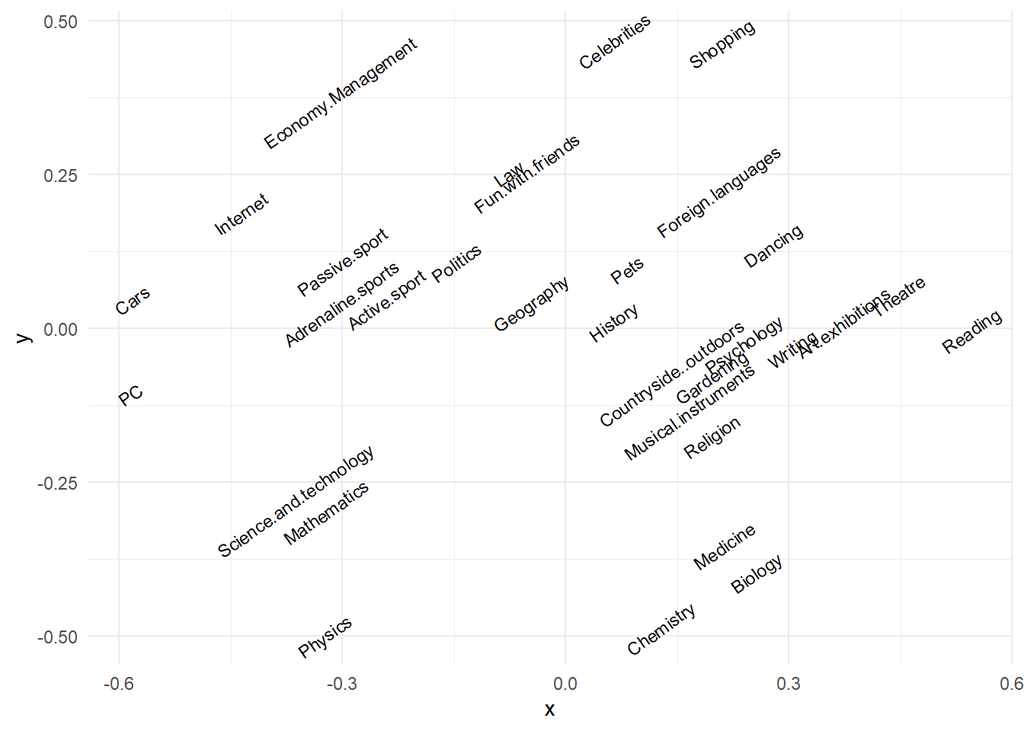

```r
ggplot(as.data.frame(mds_data),aes(x=x,y=y)) +
  geom_text(label=rownames(mds_data),size=3,angle=35) +
  labs(x="x",y="y") +
  theme_minimal()
```

We observe that subjects that have close relationship actually are plotted close to each other. For example:  
* Science and technology, mathematics and physics  
* Medicine, biology and chemistry  
* Writing, art exhibitions and theatre  
Whereas it may be interesting how “Law” and “Fun with friends” are closely located.

## 2.4 K-Means

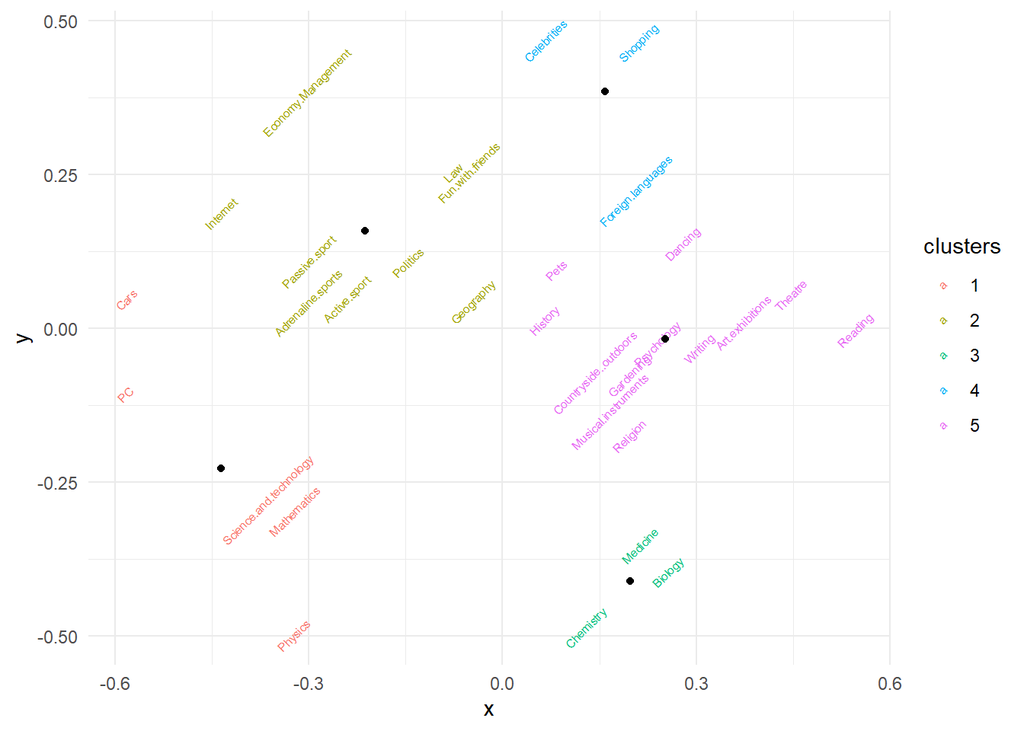

```r
set.seed(15)
subject_cluster <- kmeans(mds_data, centers=5)
mds_clusters <- data.frame(subject=names(subject_cluster$cluster),cluster_mds=subject_cluster$cluster) %>% arrange(cluster_mds,subject)

ggplot(data.frame(mds_data) %>%
         mutate(clusters=as.factor(subject_cluster$cluster),subjects=rownames(mds_data)),aes(x=x,y=y)) +
  geom_text(aes(label=subjects,color=clusters),angle=45,size=2) +
  geom_point(data=as.data.frame(subject_cluster$centers),aes(x=x,y=y)) +
  theme_minimal()
```

## 2.5 Hierarchial Clustering

I tried the methods “single”, “complete”, “average”, “centroid” and “ward.D2”. But I chose these ones to report, since they are more easy to read and I think that they respresent the relations better.

Similarly we see related subjects in the same clusters such as  
* Medicine, biology and chemistry  
* Internet and PC  
* Celebrities and shopping

### 2.5.1 Complete

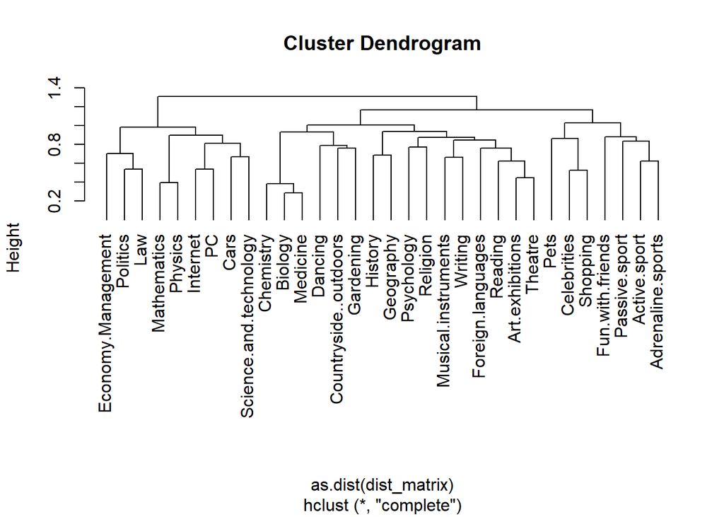

```r
hc_complete <- hclust(as.dist(dist_matrix), method = "complete")
plot(hc_complete, hang = -1)
```

### 2.5.2 Average

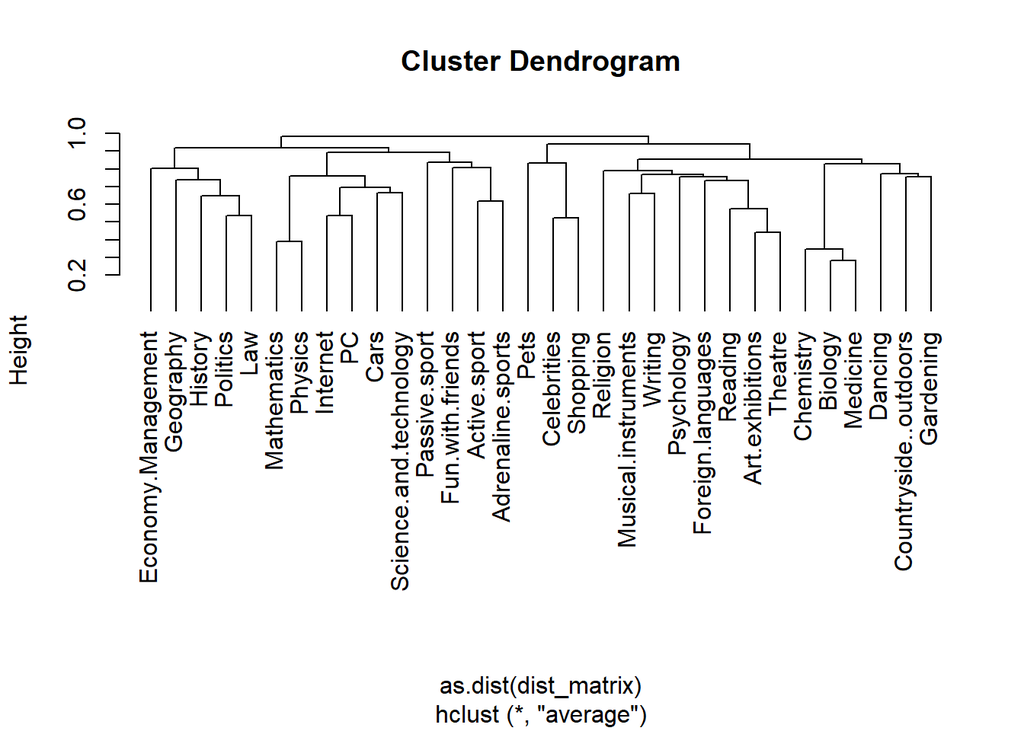

```r
hc_average <- hclust(as.dist(dist_matrix), method = "average")
plot(hc_average, hang = -1)
```

### 2.5.3 Ward.D2

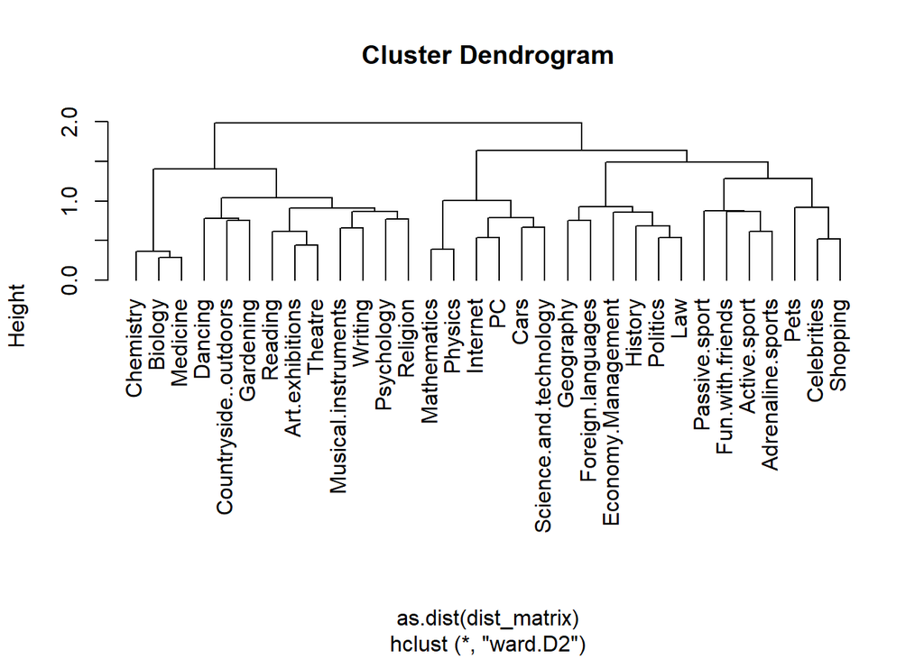

```r
hc_ward <- hclust(as.dist(dist_matrix), method = "ward.D2")
plot(hc_ward, hang = -1)
```

# 3 References

- https://stat.ethz.ch/R-manual/R-patched/library/datasets/html/esoph.html
- IE 48A Lecture Notes [Part I](https://mef-bda503.github.io/archive/fall17/files/intro_to_ml.html) & [Part II](https://mef-bda503.github.io/archive/fall17/files/intro_to_ml_2.html)
- Datacamp courses [Reporting with RMarkdown](https://campus.datacamp.com/courses/reporting-with-rmarkdown/) & [Supervised Learning in R: Regression](https://learn.datacamp.com/courses/supervised-learning-in-r-regression)
- Color palette is generated on https://palettegenerator.colorion.co/
- https://rpubs.com/sunzhe96/596831